# Codebook for BeerMerge_Cleanup

## Beer_ID

| Feature | Result |
| --- | --- |
| Variable type | integer |
| Number of missing obs. | 0 (0 %) |
| Number of unique values | 1405 |
| Median | 1439 |
| 1st and 3rd quartiles | 772; 2069 |
| Min. and max. | 1; 2692 |

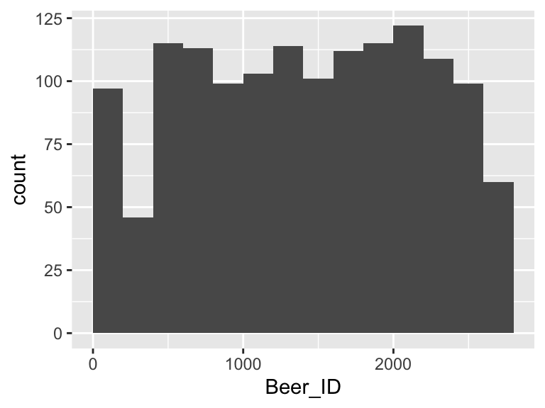

## ABV

| Feature | Result |
| --- | --- |
| Variable type | numeric |
| Number of missing obs. | 0 (0 %) |
| Number of unique values | 71 |
| Median | 0.06 |
| 1st and 3rd quartiles | 0.05; 0.07 |
| Min. and max. | 0.03; 0.12 |

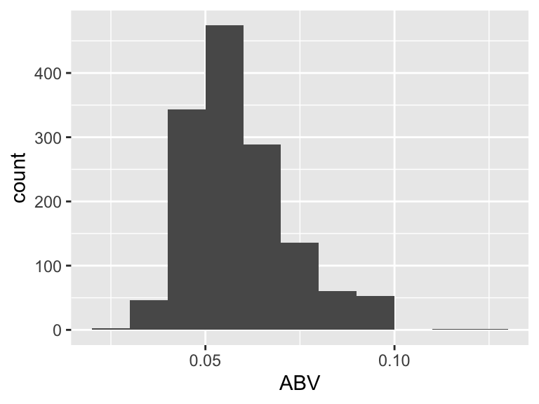

## IBU

| Feature | Result |
| --- | --- |
| Variable type | integer |
| Number of missing obs. | 0 (0 %) |
| Number of unique values | 107 |
| Median | 35 |
| 1st and 3rd quartiles | 21; 64 |
| Min. and max. | 4; 138 |

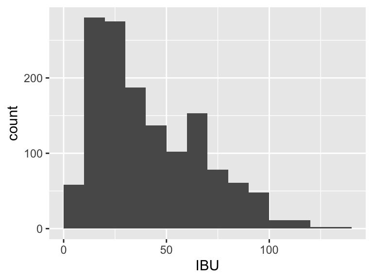

## Style

| Feature | Result |
| --- | --- |
| Variable type | factor |
| Number of missing obs. | 0 (0 %) |
| Number of unique values | 91 |
| Mode | “American IPA” |
| Reference category |  |

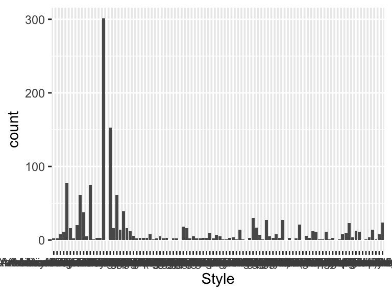

- Observed factor levels: "", "Abbey Single Ale", "Altbier", "American Adjunct Lager", "American Amber / Red Ale", "American Amber / Red Lager", "American Barleywine", "American Black Ale", "American Blonde Ale", "American Brown Ale", "American Dark Wheat Ale", "American Double / Imperial IPA", "American Double / Imperial Pilsner", "American Double / Imperial Stout", "American India Pale Lager", "American IPA", "American Malt Liquor", "American Pale Ale (APA)", "American Pale Lager", "American Pale Wheat Ale", "American Pilsner", "American Porter", "American Stout", "American Strong Ale", "American White IPA", "American Wild Ale", "Baltic Porter", "Belgian Dark Ale", "Belgian IPA", "Belgian Pale Ale", "Belgian Strong Dark Ale", "Belgian Strong Pale Ale", "Berliner Weissbier", "Bière de Garde", "Bock", "Braggot", "California Common / Steam Beer", "Chile Beer", "Cider", "Cream Ale", "Czech Pilsener", "Doppelbock", "Dortmunder / Export Lager", "Dubbel", "Dunkelweizen", "English Barleywine", "English Bitter", "English Brown Ale", "English Dark Mild Ale", "English India Pale Ale (IPA)", "English Pale Ale", "English Pale Mild Ale", "English Stout", "English Strong Ale", "Euro Dark Lager", "Euro Pale Lager", "Extra Special / Strong Bitter (ESB)", "Flanders Oud Bruin", "Flanders Red Ale", "Foreign / Export Stout", "Fruit / Vegetable Beer", "German Pilsener", "Gose", "Grisette", "Hefeweizen", "Herbed / Spiced Beer", "Irish Dry Stout", "Irish Red Ale", "Keller Bier / Zwickel Bier", "Kölsch", "Kristalweizen", "Light Lager", "Low Alcohol Beer", "Maibock / Helles Bock", "Märzen / Oktoberfest", "Mead", "Milk / Sweet Stout", "Munich Dunkel Lager", "Munich Helles Lager", "Oatmeal Stout", "Old Ale", "Other", "Pumpkin Ale", "Quadrupel (Quad)", "Radler", "Rauchbier", "Roggenbier", "Russian Imperial Stout", "Rye Beer", "Saison / Farmhouse Ale", "Schwarzbier", "Scotch Ale / Wee Heavy", "Scottish Ale", "Shandy", "Smoked Beer", "Tripel", "Vienna Lager", "Wheat Ale", "Winter Warmer", "Witbier".

## Ounces

| Feature | Result |
| --- | --- |
| Variable type | numeric |
| Number of missing obs. | 0 (0 %) |
| Number of unique values | 7 |
| Median | 12 |
| 1st and 3rd quartiles | 12; 16 |
| Min. and max. | 8.4; 32 |

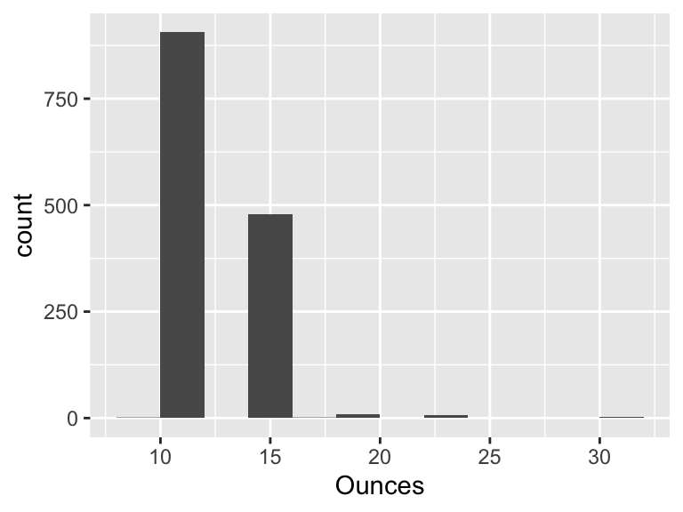

## Brewery_Name

| Feature | Result |
| --- | --- |
| Variable type | factor |
| Number of missing obs. | 0 (0 %) |
| Number of unique values | 373 |
| Mode | “Oskar Blues Brewery” |
| Reference category | 10 Barrel Brewing Company |

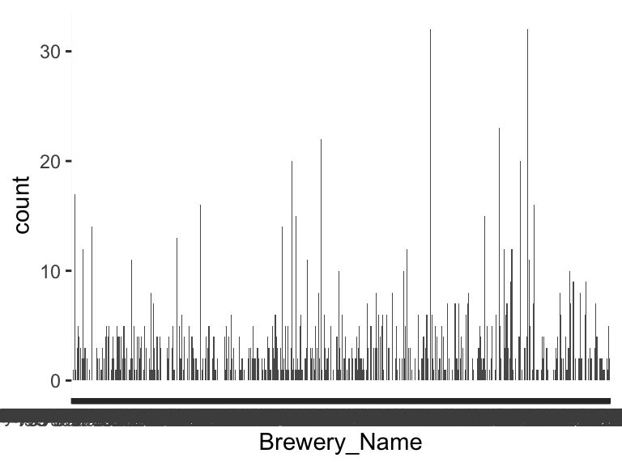

- Observed factor levels: "10 Barrel Brewing Company", "18th Street Brewery", "2 Towns Ciderhouse", "21st Amendment Brewery", "3 Daughters Brewing", "4 Hands Brewing Company", "450 North Brewing Company", "7 Seas Brewing Company", "7venth Sun", "Abita Brewing Company", "AC Golden Brewing Company", "Against the Grain Brewery", "Against The Grain Brewery", "Airways Brewing Company", "Alameda Brewing", "Alaskan Brewing Company", "Ale Asylum", "Alltech’s Lexington Brewing Company", "Amnesia Brewing Company", "Anchor Brewing Company", "Anderson Valley Brewing Company", "Angry Minnow", "Angry Minnow Brewing Company", "Angry Orchard Cider Company", "Anthem Brewing Company", "Appalachian Mountain Brewery", "Arcadia Brewing Company", "Arctic Craft Brewery", "Armadillo Ale Works", "Armstrong Brewing Company", "Asher Brewing Company", "Asheville Brewing Company", "Aslan Brewing Company", "Aspen Brewing Company", "Astoria Brewing Company", "Atwater Brewery", "Austin Beerworks", "Avery Brewing Company", "Aviator Brewing Company", "Back East Brewing Company", "Back Forty Beer Company", "Bale Breaker Brewing Company", "Ballast Point Brewing Company", "Banner Beer Company", "Bare Hands Brewery", "Barrio Brewing Company", "Base Camp Brewing Co.", "Bauhaus Brew Labs", "Baxter Brewing Company", "Beach Brewing Company", "Beer Works Brewery", "Bell’s Brewery", "Bent Brewstillery", "Bent Paddle Brewing Company", "Berkshire Brewing Company", "Big Bend Brewing Company", "Big Choice Brewing", "Big Elm Brewing", "Big Lake Brewing", "Big Muddy Brewing", "Big River Brewing Company", "Big Sky Brewing Company", "Big Storm Brewing Company", "Big Wood Brewery", "Birdsong Brewing Company", "Bitter Root Brewing", "Black Acre Brewing Co.", "Black Market Brewing Company", "Black Shirt Brewing Company", "Black Tooth Brewing Company", "Blackrocks Brewery", "Blue Blood Brewing Company", "Blue Dog Mead", "Blue Hills Brewery", "Blue Mountain Brewery", "Blue Owl Brewing", "Blue Point Brewing Company", "Bohemian Brewery", "Bold City Brewery", "Bolero Snort Brewery", "Bomb Beer Company", "Bonfire Brewing Company", "Borderlands Brewing Company", "Boston Beer Company", "Boulder Beer Company", "Boulevard Brewing Company", "Boxcar Brewing Company", "Bozeman Brewing Company", "Branchline Brewing Company", "Breakside Brewery", "Breckenridge Brewery", "Brew Bus Brewing", "Brew Link Brewing", "Brewery Terra Firma", "Brewery Vivant", "Brindle Dog Brewing Company", "Broad Brook Brewing LLC", "Broken Tooth Brewing Company", "Brooklyn Brewery", "Buckbean Brewing Company", "Buckeye Brewing", "BuckleDown Brewing", "Buffalo Bayou Brewing Company", "Burn ‘Em Brewing", "Burnside Brewing Co.", "Butcher’s Brewing", "Butternuts Beer and Ale", "Caldera Brewing Company", "Cambridge Brewing Company", "Cans Bar and Canteen", "Cape Ann Brewing Company", "Cape Cod Beer", "Capital Brewery", "Carolina Beer & Beverage", "Carolina Brewery", "Carton Brewing Company", "Cascadia Ciderworks United", "Catawba Brewing Company", "Catawba Island Brewing", "Catawba Valley Brewing Company", "Cedar Creek Brewery", "Centennial Beer Company", "Center of the Universe Brewing C…", "Central Coast Brewing Company", "Champion Brewing Company", "Chapman’s Brewing", "Chatham Brewing", "Cheboygan Brewing Company", "Christian Moerlein Brewing Company", "Churchkey Can Company", "Ciderboys", "Cigar City Brewing Company", "Cisco Brewers", "Claremont Craft Ales", "Coalition Brewing Company", "COAST Brewing Company", "Coastal Empire Beer Company", "Coastal Extreme Brewing Company", "College Street Brewhouse and Pub", "Confluence Brewing Company", "COOP Ale Works", "Core Brewing & Distilling Company", "Cottrell Brewing", "Covington Brewhouse", "Crabtree Brewing Company", "Crazy Mountain Brewing Company", "Creature Comforts", "Crooked Fence Brewing Company", "Crow Peak Brewing Company", "Crystal Springs Brewing Company", "Cutters Brewing Company", "D.L. Geary Brewing Company", "Dad & Dude’s Breweria", "Daredevil Brewing Company", "Dave’s Brewfarm", "David’s Ale Works", "DC Brau Brewing Company", "Dead Armadillo Craft Brewing", "Deep Ellum Brewing Company", "Defiance Brewing Company", "Denali Brewing Company", "Denver Beer Company", "Deschutes Brewery", "Destihl Brewery", "Devil’s Backbone Brewing Company", "Devil’s Canyon Brewery", "Dick’s Brewing Company", "Dirty Bucket Brewing Company", "Dock Street Brewery", "Dolores River Brewery", "Downeast Cider House", "Dry Dock Brewing Company", "Due South Brewing Company", "Dundee Brewing Company", "Eddyline Brewery & Restaurant", "Elevator Brewing Company", "Emerald City Beer Company", "Engine 15 Brewing", "Engine House 9", "Epic Brewing", "Everybody’s Brewing", "Evil Czech Brewery", "Evil Twin Brewing", "Fargo Brewing Company", "Fat Head’s Brewery", "Fate Brewing Company", "Fearless Brewing Company", "Fiddlehead Brewing Company", "Figueroa Mountain Brewing Company", "Finch’s Beer Company", "Firestone Walker Brewing Company", "Flat 12 Bierwerks", "Flat Rock Brewing Company", "Flesk Brewing Company", "Flying Dog Brewery", "Flying Mouse Brewery", "Foolproof Brewing Company", "Forgotten Boardwalk", "Fort George Brewery", "Fort Pitt Brewing Company", "Fort Point Beer Company", "Founders Brewing Company", "Four Corners Brewing Company", "Four Fathers Brewing ", "Four Horsemen Brewing Company", "Four Peaks Brewing Company", "Four String Brewing Company", "Frankenmuth Brewery", "Freetail Brewing Company", "Fremont Brewing Company", "French Broad Brewery", "Frog Level Brewing Company", "Fullsteam Brewery", "Geneva Lake Brewing Company", "Glabrous Brewing Company", "Golden Road Brewing", "Gonzo’s BiggDogg Brewing", "Good Life Brewing Company", "Good People Brewing Company", "Goodlife Brewing Co.", "Goose Island Brewery Company", "Goose Island Brewing Company", "Gore Range Brewery", "Grand Canyon Brewing Company", "Grapevine Craft Brewery", "Great Crescent Brewery", "Great Divide Brewing Company", "Great Northern Brewing Company", "Great Raft Brewing Company", "Great River Brewery", "Green Room Brewing", "Greenbrier Valley Brewing Company", "Grey Sail Brewing Company", "Grey Sail Brewing of Rhode Island", "Griffin Claw Brewing Company", "Grimm Brothers Brewhouse", "Hale’s Ales", "Half Acre Beer Company", "Half Full Brewery", "Hangar 24 Craft Brewery", "Hardywood Park Craft Brewery", "Harpoon Brewery", "Harvest Moon Brewing Company", "Hawai’i Nui Brewing Co.", "Headlands Brewing Company", "Heavy Seas Beer", "Hess Brewing Company", "High Hops Brewery", "High Noon Saloon And Brewery", "Hilliard’s Beer", "Hinterland Brewery", "Hop Farm Brewing Company", "Hop Valley Brewing Company", "Hops & Grain Brewery", "Hops & Grains Brewing Company", "Hopworks Urban Brewery", "Horny Goat Brew Pub", "Howard Brewing Company", "Indeed Brewing Company", "Independence Brewing Company", "Indiana City Brewing", "Infamous Brewing Company", "Intuition Ale Works", "Ipswich Ale Brewery", "Iron Hill Brewery & Restaurant", "Jack’s Abby Craft Lagers", "Jack’s Hard Cider (Hauser Estate…", "Jackalope Brewing Company", "Jackie O’s Pub & Brewery", "Jailbreak Brewing Company", "James Page Brewing Company", "Joseph James Brewing Company", "Kalona Brewing Company", "Karbach Brewing Company", "KelSo Beer Company", "Kenai River Brewing Company", "Kettle House Brewing Company", "Keweenaw Brewing Company", "King Street Brewing Company", "Kirkwood Station Brewing Company", "Kona Brewing Company", "Krebs Brewing Company (Pete’s Pl…", "Kulshan Brewery", "La Cumbre Brewing Company", "Lancaster Brewing Company", "Latitude 42 Brewing Company", "Laughing Dog Brewing Company", "Lavery Brewing Company", "Lazy Monk Brewing", "Lewis and Clark Brewing Company", "Lift Bridge Brewing Company", "Liquid Hero Brewery", "Lone Tree Brewing Company", "Lonerider Brewing Company", "Long Trail Brewing Company", "Lost Nation Brewing", "Lost Rhino Brewing Company", "Lucette Brewing Company", "Lucky Town Brewing Company", "Lumberyard Brewing Company", "Macon Beer Company", "MacTarnahans Brewing Company", "Madtree Brewing Company", "Magic Hat Brewing Company", "Mammoth Brewing Company", "Manayunk Brewing Company", "Manzanita Brewing Company", "Marble Brewery", "Marshall Wharf Brewing Company", "Martin House Brewing Company", "Matt Brewing Company", "Maui Brewing Company", "Mavericks Beer Company", "Meckley’s Cidery", "Mehana Brewing Co.", "Miami Brewing Company", "Mickey Finn’s Brewery", "Midnight Sun Brewing Company", "Mike Hess Brewing Company", "Mikerphone Brewing", "Mikkeller", "MillKing It Productions", "Milwaukee Brewing Company", "Minhas Craft Brewery", "Mission Brewery", "Moab Brewery", "Moat Mountain Smoke House & Brew…", "Modern Monks Brewery", "Modern Times Beer", "Mogollon Brewing Company", "Monkey Paw Pub & Brewery", "Montauk Brewing Company", "Morgan Street Brewery", "Mother Earth Brew Company", "Mother Earth Brewing Company", "Mother’s Brewing", "Mountain Town Brewing Company ", "Mudshark Brewing Company", "Mustang Brewing Company", "Narragansett Brewing Company", "Natian Brewery", "Nebraska Brewing Company", "Neshaminy Creek Brewing Company", "New Belgium Brewing Company", "New England Brewing Company", "New Orleans Lager & Ale Brewing …", "New Republic Brewing Company", "New South Brewing Company", "Newburgh Brewing Company", "Newburyport Brewing Company", "Night Shift Brewing", "NoDa Brewing Company", "North Country Brewing Company", "Northampton Brewery", "NorthGate Brewing ", "Northwest Brewing Company", "Northwoods Brewpub", "Notch Brewing Company", "O’Fallon Brewery", "Oakshire Brewing", "Oasis Texas Brewing Company", "Occidental Brewing Company", "Odyssey Beerwerks", "Okoboji Brewing Company", "Old Forge Brewing Company", "Orlison Brewing Company", "Orpheus Brewing", "Oskar Blues Brewery", "Oskar Blues Brewery (North Carol…", "Otter Creek Brewing", "Ozark Beer Company", "Palisade Brewing Company", "Pateros Creek Brewing Company", "Payette Brewing Company", "Peace Tree Brewing Company", "Peak Organic Brewing Company", "Pedernales Brewing Company", "People’s Brewing Company", "Perrin Brewing Company", "Pete’s Brewing Company", "Petoskey Brewing", "Phoenix Ale Brewery", "Pikes Peak Brewing Company", "Pine Street Brewery", "Piney River Brewing Company", "Pipeworks Brewing Company", "Pisgah Brewing Company", "Pizza Port Brewing Company", "Platform Beer Company", "Pollyanna Brewing Company", "Portside Brewery", "Prescott Brewing Company", "Pug Ryan’s Brewery", "Pyramid Breweries", "Quest Brewing Company", "Rahr & Sons Brewing Company", "Real Ale Brewing Company", "Red Hare Brewing Company", "Red Shedman Farm Brewery and Hop…", "Red Tank Cider Company", "Redhook Brewery", "Redstone Meadery", "Refuge Brewery", "Renegade Brewing Company", "Revolution Brewing", "Revolution Brewing Company", "Rhinegeist Brewery", "Right Brain Brewery", "Rising Tide Brewing Company", "River North Brewery", "Rivertown Brewing Company", "Rivertowne Brewing Company", "Roanoke Railhouse Brewery", "Rochester Mills Brewing Company", "Rogue Ales", "RoughTail Brewing Company", "Round Guys Brewing", "Ruhstaller Beer Company", "Saint Archer Brewery", "Sanitas Brewing Company", "Santa Cruz Mountain Brewing", "Santa Fe Brewing Company", "SanTan Brewing Company", "Saugatuck Brewing Company", "Schilling & Company", "Schlafly Brewing Company", "Sea Dog Brewing Company", "Seabright Brewery", "Seattle Cider Company", "Seven Brides Brewery", "Seventh Son Brewing Company", "Shebeen Brewing Company", "Sherwood Forest Brewers", "Shipyard Brewing Company", "Sierra Nevada Brewing Company", "Sietsema Orchards and Cider Mill", "Silverton Brewery", "Sixpoint Craft Ales", "Ska Brewing Company", "Slanted Rock Brewing Company", "SlapShot Brewing Company", "Sleeping Lady Brewing Company", "Sly Fox Brewing Company", "Smartmouth Brewing Company", "Snake River Brewing Company", "Sockeye Brewing Company", "South Austin Brewery", "Southampton Publick House", "Southern Oregon Brewing Company", "Southern Prohibition Brewing Com…", "Southern Star Brewing Company", "Speakasy Ales & Lagers", "Spilker Ales", "Spiteful Brewing Company", "Sprecher Brewing Company", "Spring House Brewing Company", "St. Julian Winery", "Starr Hill Brewery", "Steamworks Brewing Company", "Stevens Point Brewery", "Stillmank Beer Company", "Stillwater Artisanal Ales", "Stone Coast Brewing Company", "Straight to Ale", "Straub Brewery", "Summit Brewing Company", "Sun King Brewing Company", "Sunken City Brewing Company", "Surly Brewing Company", "Swamp Head Brewery", "Swashbuckler Brewing Company", "SweetWater Brewing Company", "TailGate Beer", "Tallgrass Brewing Company", "Tamarack Brewing Company", "Tampa Bay Brewing Company", "Tapistry Brewing", "Taxman Brewing Company", "Telluride Brewing Company", "Temperance Beer Company", "Terrapin Brewing Company", "Texian Brewing Co.", "The Alchemist", "The Black Tooth Brewing Company", "The Brewer’s Art", "The Bronx Brewery", "The Dudes’ Brewing Company", "The Just Beer Project", "The Lion Brewery", "The Manhattan Brewing Company", "The Mitten Brewing Company", "The Right Brain Brewery", "The Traveler Beer Company", "Third Street Brewhouse", "Thomas Hooker Brewing Company", "Three Creeks Brewing", "Three Notch’d Brewing Company", "Three Pints Brewing", "Thunderhead Brewing Company", "Tin Man Brewing Company", "Tin Roof Brewing Company", "Tommyknocker Brewery", "Tonka Beer Company", "Tractor Brewing Company", "Triangle Brewing Company", "Tröegs Brewing Company", "Twin Lakes Brewing Company", "Twisted Pine Brewing Company", "Twisted X Brewing Company", "Two Beers Brewing Company", "Two Brothers Brewing Company", "Two Henrys Brewing Company", "Two Roads Brewing Company", "Uinta Brewing Company", "Ukiah Brewing Company", "Uncle Billy’s Brewery and Smokeh…", "Uncle John’s Fruit House Winery", "Uncommon Brewers", "Union Craft Brewing", "Upland Brewing Company", "Upslope Brewing Company", "Upstate Brewing Company", "Utah Brewers Cooperative", "Vander Mill Ciders", "Vault Brewing Company", "Voodoo Brewery", "Wachusett Brewing Company", "Warbird Brewing Company", "Warped Wing Brewing Company", "West Sixth Brewing", "Westbrook Brewing Company", "Westfield River Brewing Company", "Weston Brewing Company", "White Birch Brewing", "White Flame Brewing Company", "Widmer Brothers Brewing Company", "Wild Onion Brewing Company", "Wild Wolf Brewing Company", "Wildwood Brewing Company", "Wind River Brewing Company", "Wingman Brewers", "Wisconsin Brewing Company", "Wiseacre Brewing Company", "Witch’s Hat Brewing Company", "Wolf Hills Brewing Company", "Wolverine State Brewing Company", "Woodchuck Hard Cider", "Woodstock Inn, Station & Brewery", "Wormtown Brewery", "Worthy Brewing Company", "Wynkoop Brewing Company".

## City

| Feature | Result |
| --- | --- |
| Variable type | factor |
| Number of missing obs. | 0 (0 %) |
| Number of unique values | 281 |
| Mode | “Portland” |
| Reference category | Abingdon |

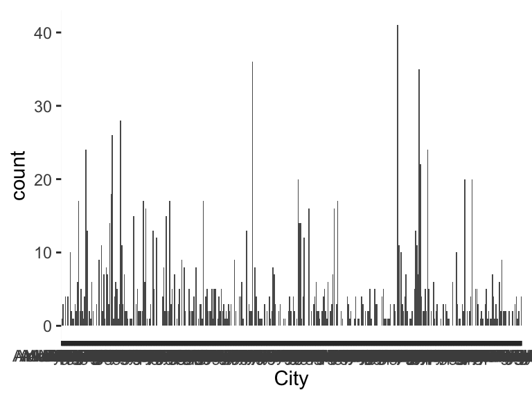

- Observed factor levels: "Abingdon", "Abita Springs", "Ada", "Afton", "Airway Heights", "Albuquerque", "Alpine", "Anchorage", "Angola", "Ann Arbor", "Arrington", "Arvada", "Ashburn", "Asheville", "Ashland", "Aspen", "Astoria", "Athens", "Atlanta", "Atlantic Highlands", "Aurora", "Austin", "Avon", "Baltimore", "Bargersville", "Baton Rouge", "Battle Creek", "Belfast", "Bellingham", "Belmont", "Belt", "Bend", "Biglerville", "Birmingham", "Black Mountain", "Blanco", "Bloomfield", "Bloomington", "Boise", "Boone", "Boonville", "Boston", "Boulder", "Boynton Beach", "Bozeman", "Brevard", "Bridgewater Corners", "Bridgman", "Bronx", "Brooklyn", "Brooklyn Center", "Broomfield", "Bucryus", "Buellton", "Buena Vista", "Burlington", "Cambridge", "Canton", "Carlsbad", "Centralia", "Chandler", "Charleston", "Charlotte", "Charlottesville", "Chatham", "Chattanooga", "Cheboygan", "Cherry Hill", "Chicago", "Chico", "Cincinnati", "Claremont", "Cleveland", "Cold Spring", "College Station", "Colorado Springs", "Columbus", "Comstock Park", "Conestoga", "Conroe", "Cortland", "Corvallis", "Covington", "Croydon", "Crozet", "Dallas", "Danville", "Davenport", "Dayton", "Denton", "Denver", "Des Moines", "Detroit", "Diamond Springs", "Dillon", "Dolores", "Douglas", "Dripping Springs", "Duluth", "Dunedin", "Durango", "Durham", "Eagle", "East Fairfield", "East Windsor", "Eau Claire", "Edwards", "Elmira", "Erie", "Estacada", "Eugene", "Evanston", "Evansville", "Everett", "Export", "Fargo", "Farmers Branch", "Flagstaff", "Fort Collins", "Fort Wayne", "Fort Worth", "Framingham", "Frankenmuth", "Frederick", "Fredericksburg", "Fuquay-Varina", "Gadsden", "Gainesville", "Garden City", "Garrattsville", "Gary", "Gig Harbor", "Glendale", "Gloucester", "Golden", "Grand Rapids", "Granger", "Greeley", "Green Bay", "Greenville", "Halethorpe", "Half Moon Bay", "Hamilton", "Hardy", "Hattiesburg", "Hays", "Hayward", "Helena", "Henderson", "Hershey", "Hilo", "Holland", "Hooksett", "Houghton", "Houston", "Hudsonville", "Huntsville", "Hyannis", "Idaho Springs", "Indianapolis", "Ipswich", "Jackson", "Jacksonville", "Jacksonville Beach", "Juneau", "Kalamazoo", "Kalona", "Kansas City", "Kearney", "Kent", "Kinston", "Kirkwood", "Knoxville", "Kona", "Krebs", "Lafayette", "Lahaina", "Lake Barrington", "Lake Geneva", "Lake Havasu City", "Lakeside", "Lancaster", "Lansdale", "Latrobe", "Laurel", "Leavenworth", "Lemont", "Lenoir", "Leominster", "Lewisburg", "Lewiston", "Lexington", "Libertyville", "Lincoln", "Lockland", "Lombard", "Lone Tree", "Longmont", "Los Angeles", "Louisville", "Loveland", "Lowell", "Lyons", "Macon", "Madison", "Mammoth Lakes", "Manhattan", "Manheim", "Marietta", "Marlborough", "Marquette", "Martinsville", "Meadville", "Medford", "Memphis", "Menominee", "Menominie", "Meridian", "Miami", "Michigan City", "Middleburg Heights", "Middlebury", "Middleton", "Midvale", "Midwest City", "Mill Valley", "Milwaukee", "Minneapolis", "Minnetonka", "Mishawaka", "Missoula", "Moab", "Monroe", "Montauk", "Monument", "Mooresville", "Morganton", "Mount Pleasant", "Mt. Airy", "Mt. Pleasant", "Murphysboro", "Mustang", "Myrtle Beach", "Nantucket", "Nashville", "Nellysford", "New Orleans", "New York", "Newburgh", "Newburyport", "Newport", "Norfolk", "North Conway", "North Woodstock", "Northamtpon", "O’Fallon", "Odessa", "Oklahoma City", "Pacific", "Palisade", "Paonia", "Papillion", "Paso Robles", "Patchogue", "Paw Paw", "Pawcatuck", "Pawtucket", "Petoskey", "Philadelphia", "Phoenix", "Phoenixville", "Pinedale", "Pineland", "Pittsboro", "Pittsburgh", "Plainfield", "Plant City", "Ponderay", "Port Clinton", "Portage", "Portland", "Pottstown", "Prescott", "Providence", "Raleigh", "Redlands", "Reno", "Richmond", "Ridgefield Park", "Roanoke", "Rochester", "Rogers", "Roseville", "Royal Oak", "Sacramento", "Saint Louis", "Salt Lake City", "San Antonio", "San Diego", "San Francisco", "San Luis Obispo", "Santa Cruz", "Santa Fe", "Santee", "Savannah", "Seattle", "Seven Points", "Sheffield", "Shelburne", "Shelbyville", "Sheridan", "Shreveport", "Silverton", "Sisters", "Slippery Rock", "Smithton", "Soldotna", "Somerset Center", "South Austin", "South Bend", "South Burlington", "South Deerfield", "South Lyon", "South San Francisco", "Southampton", "Spearfish", "Spirit Lake", "Spring Lake", "Springdale", "Springfield", "St Mary’s", "St Paul", "St Petersburg", "St. John’s", "St. Paul", "Stamford", "Stevens Point", "Stevensville", "Stillwater", "Stratford", "Tacoma", "Talkeetna", "Tampa", "Tampa Bay", "Telluride", "Temecula", "Tempe", "Torrance", "Traverse City", "Troutville", "Tucson", "Tulsa", "Ukiah", "Utica", "Vadnais Heights", "Valparaiso", "Verona", "Virginia Beach", "Vista", "Warrenville", "Washington", "Washougal", "Waterbury", "Waynesville", "West Chester", "Westerly", "Westfield", "Westminster", "Weston", "White Salmon", "Whitefish", "Wilkes-Barre", "Williams", "Williamsburg", "Wilmington", "Wilson", "Windsor", "Wolcott", "Woodbridge", "Woodinville", "Worcester", "Yakima", "Yardley", "York".

## State

| Feature | Result |
| --- | --- |
| Variable type | character |
| Number of missing obs. | 0 (0 %) |
| Number of unique values | 50 |
| Mode | “CO” |

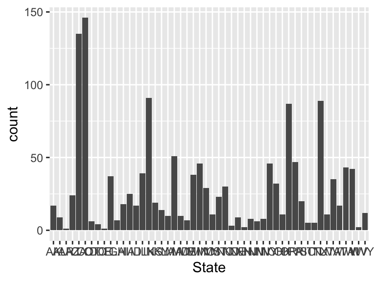

- Observed factor levels: "AK", "AL", "AR", "AZ", "CA", "CO", "CT", "DC", "DE", "FL", "GA", "HI", "IA", "ID", "IL", "IN", "KS", "KY", "LA", "MA", "MD", "ME", "MI", "MN", "MO", "MS", "MT", "NC", "ND", "NE", "NH", "NJ", "NM", "NV", "NY", "OH", "OK", "OR", "PA", "RI", "SC", "TN", "TX", "UT", "VA", "VT", "WA", "WI", "WV", "WY".

Report generation information:

- Created by: Akbar Thobani (username: `03154669`).
- Report creation time: Fri Feb 28 2020 17:19:48
- Report was run from directory: `/Users/03154669/Downloads`
- dataMaid v1.4.0 [Pkg: 2019-12-10 from CRAN (R 3.6.0)]
- R version 3.6.1 (2019-07-05).
- Platform: x86_64-apple-darwin15.6.0 (64-bit)(macOS Mojave 10.14.5).
- Function call: `dataMaid::makeDataReport(data = BeerMerge_Cleanup, mode = c("summarize", "visualize", "check"), smartNum = FALSE, file = "codebook_BeerMerge_Cleanup.Rmd", checks = list(character = "showAllFactorLevels", factor = "showAllFactorLevels", labelled = "showAllFactorLevels", haven_labelled = "showAllFactorLevels", numeric = NULL, integer = NULL, logical = NULL, Date = NULL), listChecks = FALSE, maxProbVals = Inf, codebook = TRUE, reportTitle = "Codebook for BeerMerge_Cleanup")`